# ASM - Project TS

### Analysis of Residuals

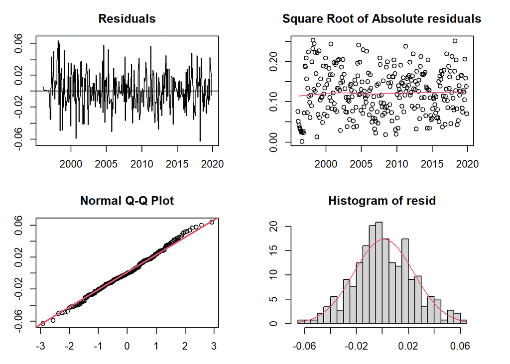

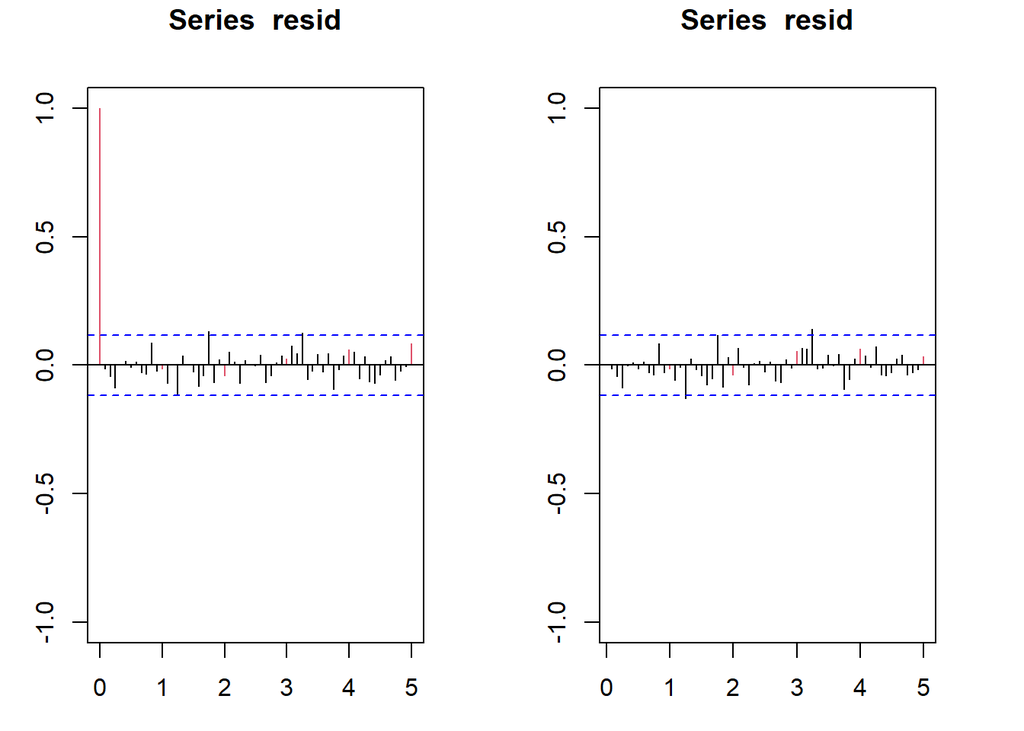

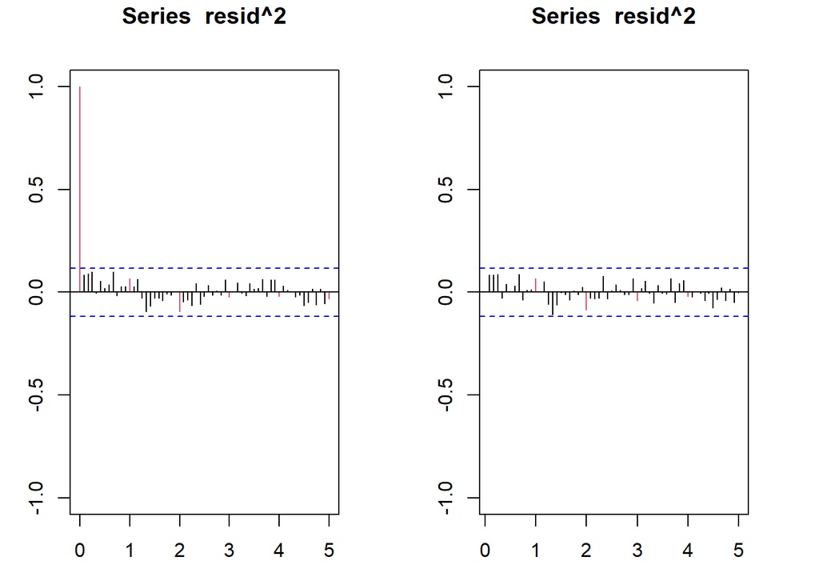

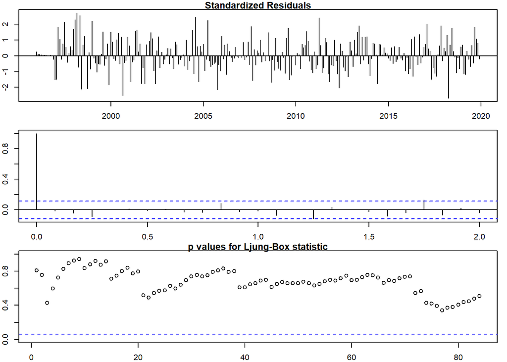

```
##
## --------------------------------------------------------------------
##
## Call:
## arima(x = lnserieEC.lin, order = c(2, 1, 0), seasonal = list(order = c(1, 1,
##     0), period = 12))
##
## Coefficients:
##           ar1      ar2     sar1
##       -0.4307  -0.2620  -0.1486
## s.e.   0.0583   0.0592   0.0630
##
## sigma^2 estimated as 0.0005486:  log likelihood = 641.89,  aic = -1275.78
##
## Modul of AR Characteristic polynomial Roots:  1.17221 1.17221 1.17221 1.17221 1.17221 1.17221 1.17221 1.17221 1.17221 1.17221 1.17221 1.17221 1.953576 1.953576
##
## Modul of MA Characteristic polynomial Roots:
```

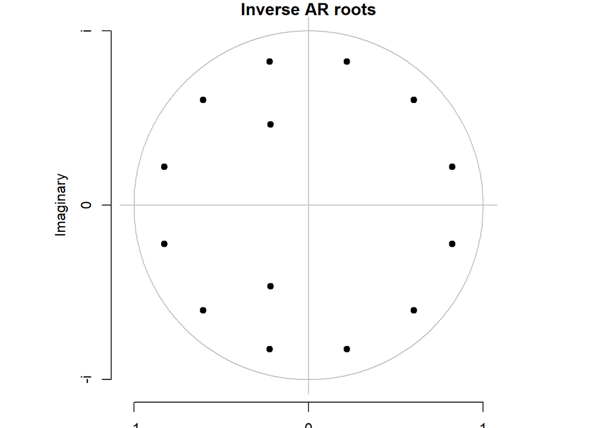

```
##
## Psi-weights (MA(inf))
##
## --------------------
##         psi 1         psi 2         psi 3         psi 4         psi 5
## -4.306641e-01 -7.655150e-02  1.458119e-01 -4.273769e-02 -1.980049e-02
##         psi 6         psi 7         psi 8         psi 9        psi 10
##  1.972562e-02 -3.306931e-03 -3.744391e-03  2.479067e-03 -8.652835e-05
##        psi 11        psi 12        psi 13        psi 14        psi 15
## -6.123080e-04 -1.482844e-01  6.402122e-02  1.128230e-02 -2.163392e-02
##        psi 16        psi 17        psi 18        psi 19        psi 20
##  6.360728e-03  2.929248e-03 -2.928179e-03  4.935312e-04  5.547043e-04
##
## Pi-weights (AR(inf))
##
## --------------------
##        pi 1        pi 2        pi 3        pi 4        pi 5        pi 6
## -0.43066408 -0.26202305  0.00000000  0.00000000  0.00000000  0.00000000
##        pi 7        pi 8        pi 9       pi 10       pi 11       pi 12
##  0.00000000  0.00000000  0.00000000  0.00000000  0.00000000 -0.14857081
##       pi 13       pi 14       pi 15       pi 16       pi 17       pi 18
## -0.06398411 -0.03892898  0.00000000  0.00000000  0.00000000  0.00000000
##       pi 19       pi 20
##  0.00000000  0.00000000
##
## Normality Tests
##
## --------------------
##
##  Shapiro-Wilk normality test
##
## data:  resid(model)
## W = 0.99561, p-value = 0.5948
##
##
##  Anderson-Darling normality test
##
## data:  resid(model)
## A = 0.44074, p-value = 0.2886
##
```

[output cut: 23 more lines]

```
## data:  resid(model) ~ I(1:length(resid(model)))
## DW = 2.032, p-value = 0.5842
## alternative hypothesis: true autocorrelation is greater than 0
##
##
## Ljung-Box test
##      lag.df   statistic   p.value
## [1,]      1  0.05957926 0.8071622
## [2,]      2  0.56254098 0.7548241
## [3,]      3  2.75828358 0.4304133
## [4,]      4  2.76172076 0.5984583
## [5,]     12  5.93093935 0.9195232
## [6,]     24 22.13327499 0.5713122
## [7,]     36 27.84864920 0.8325510
## [8,]     48 43.49837518 0.6576270
```

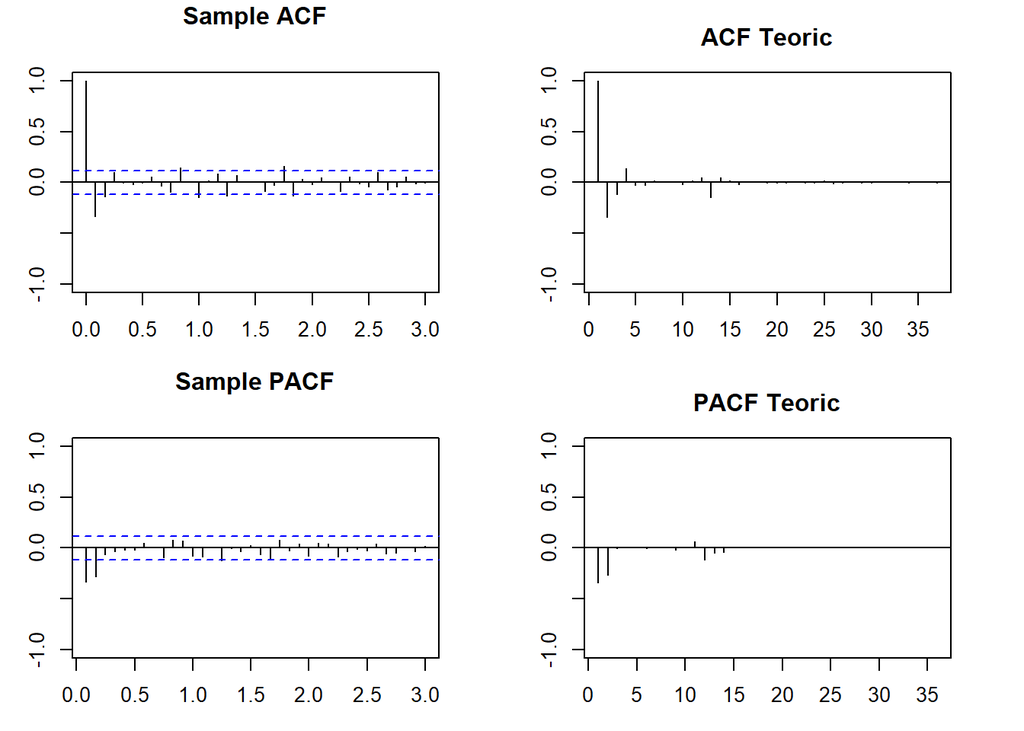

```r
dades=d1d12lnserie.lin  #stationary
model=mod3  #Fitted ARIMA model to the log-linearized series
validation(model,dades)
```

By looking at the corresponding graphic of residuals and their squared root residuals, we can consider it to have a more less constant variance. Although there are some exceptions, they can be considered minimal. When we pay attention to the Normal QQ plot, it becomes visible that the residuals do mostly align with the normal distribution. This fact is confirmed by the Saphiro-Wilk Test, which provides a p-value that does not allow the rejection of normality.